# The Use of Force by Police

Anthony Lee, Niranjanaa Kannan, Munir Emam, Dev Dhawan

11/14/2022

## Dynamic Paragraph

The data sets pertain to use of force by police officers, aggregated by geographic regions, gender, and race. In our findings, the mode for gender subjected to use of force was seen to be males, with 11011 cases of male victims in Seattle compared to 3139 female victims in Seattle. In addition there was 2779 male victims in Dallas, compared to only 590 female victims in Dallas. This is a stark skew in the data set, as the most common gender in use of force cases pertains to males by several times more than female.

The data sets also records the race of victims in incidents involving the use of force. The races recorded in the Seattle data set were Black or African American, White, Asian, Not Specified, American Indian/Alaska Native, Hispanic or Latino, Nat Hawaiian/Oth Pac Islander, Two or More Races. The races recorded in Dallas were Black, Hispanic, White, Asian, Unknown, NULL, American Ind, Other. The race counts let us analyze whether certain groups are more prone to be victims of the use of force.

The New Orleans data set provided information on outside factors involved in the use of force incidents. Outside factors recorded include Mentally unstable, Agitated, None detected, Alchohol, Unknown Drugs, Incoherent, Alchohol and unknown drugs, Unknown, Poor hygiene, Marijuana, NULL, Talking to themselves, Animal. These factors allowed us to further analyze whether certain groups of people are more likely to be involved in use of force incidents.

To try and discover how many incidents are deemed as unjustified, the New Orleans data set provides information on the number of incidents that the New Orleans Police Department deems as unjustified. Based on the data set, the number of unjustified incidents was 48 equating to a proportion of 0.0160321. However, there is limited information on what is unjustified and it is based off the discretion of the police departments investigation.

These visual summaries of the overall use of force data allow one to put forth data-driven analysis on specific factors within use-of-force incidents and make data-driven conclusions. However, there are still some limitations, including context for overall population and further segmentation of factors that impact use of force. Nonetheless, the data still points towards numbers that can be used to reasonably identify key factors in use of force incidents.

## Table

| Race | Seattle Race Count | Race | Dallas Race Count | Race | New Orleans Race Count |
| --- | --- | --- | --- | --- | --- |
| American Indian/Alaska Native | 228 | American Ind | 6 | Asian | 24 |
| Asian | 495 | Asian | 7 | Black | 3014 |
| Black or African American | 4886 | Black | 1957 | Hispanic | 83 |
| Hispanic or Latino | 679 | Hispanic | 687 | Indian | 5 |
| Nat Hawaiian/Oth Pac Islander | 129 | NULL | 78 | Race-Unknown | 12 |
| Not Specified | 2376 | Other | 13 | White | 473 |
| Two or More Races | 41 | Unknown | 16 | NA | NA |
| White | 5888 | White | 644 | NA | NA |

## Graph 1

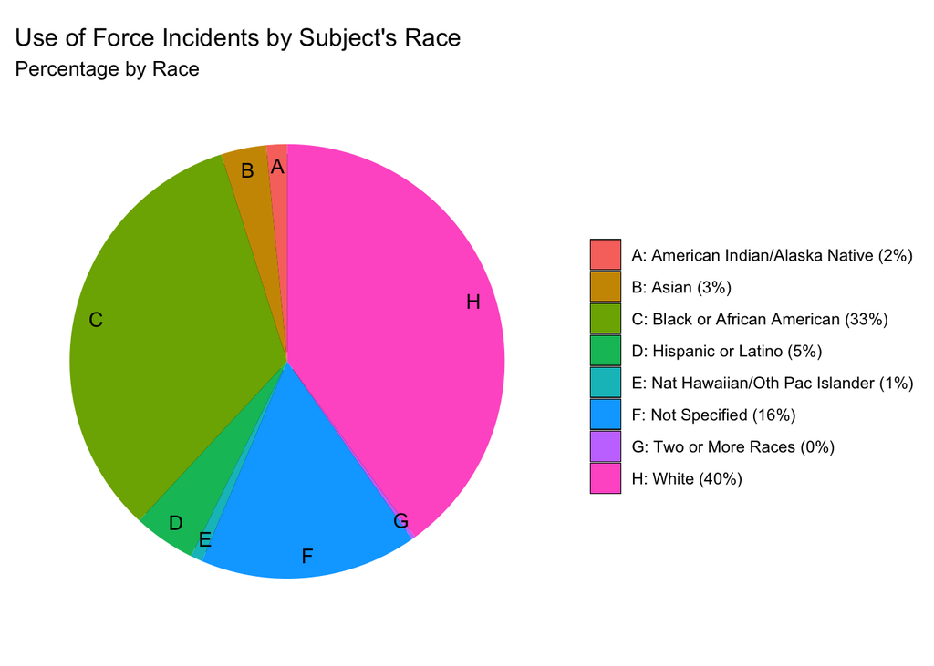

The purpose of the pie chart is to show the percentage of force being used on a subject based on race. The pie chart allows us to identify trends in which groups are more likely to be subject of the use of force by law enforcement. Observations that can be made from the pie chart is that Blacks or African Americans and Whites account for a large majority of subjects in incidents involving the use of force. However, the Blacks or African Americans account for a significantly less proportion of the US population when compared to Whites. This may point to systematic racism.

## Graph 2

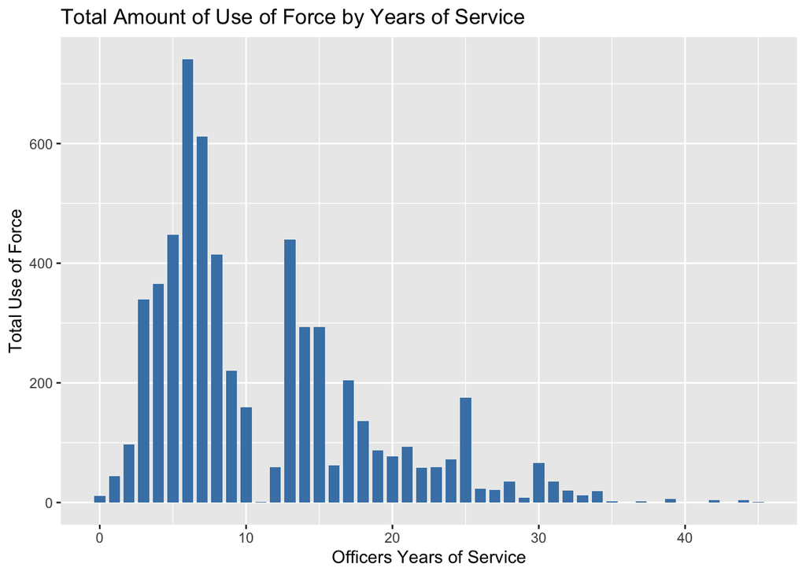

## Graph 3

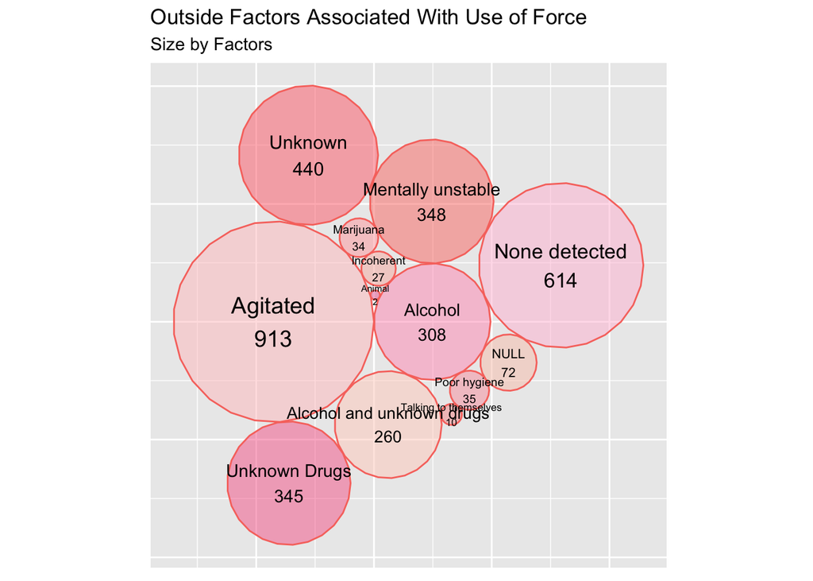